# Predicting Exercise Quality from Accelerometer Data with Machine Learning

Author: Jovan Sardinha  
Email: jovan.sardinha@gmail.com  
Date: Friday, July 24, 2014

## Executive Summary

The report details the building of machine learning models which predicts the *classe* (quality of exercise) variable from data provided by accelerometer. To do this, 5 classification models were initially selected and the best, in terms of accuracy, was fine tuned to improve the overall prediction capability. The goal was to predict the *classe* variable for 5 exercise performed by 6 different participants.

The performance specifications of the final model are outlined below:

| Model Name | Out of Sample Accuracy | 95% Confidence Interval for Accuracy | No Information Rate (NIR) | P-Value [Accuracy > NIR] | Kappa | Mcnemar’s Test P-Value |
| --- | --- | --- | --- | --- | --- | --- |
| Final Model :Random Forest Model with K-Fold Cross Validation | 0.982 | (0.98, 0.984) | 0.287 | <2e-16 (Significant) | 0.978 | N/A |

## 1.0 - Background

Using devices such as Jawbone Up, Nike FuelBand, and Fitbit it is now possible to collect a large amount of data about personal activity relatively inexpensively. These type of devices are part of the quantified self movement - a group of enthusiasts who take measurements about themselves regularly to improve their health, to find patterns in their behaviour, or because they are tech geeks. One thing that people regularly do is quantify how much of a particular activity they do, but they rarely quantify how well they do it.

## 2.0 - Purpose and Scope

Data from accelerometers on the belt, forearm, arm, and dumbell of 6 participants were utilized. These participants were asked to perform barbell lifts correctly and incorrectly in 5 different ways with machine learning models. More information is available from the website here: http://groupware.les.inf.puc-rio.br/har.

## 3.0 - Data Preparation

The following section details the procedure required to prepare the data for analysis. This includes getting the data, cleaning it and then splitting it.

### 3.1 - Getting that Data

The data sets used here include:

1. Training data set:
- location: https://d396quszas40orc.cloudfront.net/predmachlearn/pml-training.csv
- dimensions: 19622 observations of 160 variables
- data extracted on: Monday, July 21, 2014 @ 12:41 AM
2. Testing data set:
- location: https://d396qusza40orc.cloudfront.net/predmachlearn/pml-testing.csv
- dimensions: 20 observations of 160 variables
- data extracted on: Monday, July 21, 2014 @ 12:41 AM

Since the testing data set only consists of 0.10% of the total available data, the training data set will be split into a cross validation data set to prevent over-fitting and get an out of sample error rate (for further details on the cross-validation (CV) data set, please see *section 3.3*)

```r
# Importing data into memory
trainData <- read.csv(trainFile)
testData <- read.csv(testFile)
```

### 3.2 - Cleaning the Data

```r
# Identifying tracking specific variables
toMatch <- c("X", "user_name", "raw_timestamp_part_1", "raw_timestamp_part_2", "cvtd_timestamp", "new_window", "num_window")
removeColumns <- grep(paste(toMatch,collapse="|"), colnames(trainData))

# Identifying Zero Varience Values
nzv <- nearZeroVar(trainData, saveMetrics = TRUE)
removeColumns <- c(removeColumns,which(nzv$nzv == TRUE))

# Identifying aggregate specific variables
AggregateVals <- names(trainData[,colSums(is.na(trainData), na.rm = FALSE) > 0.95*nrow(trainData)])
NAColumns <- grep(paste(AggregateVals,collapse="|"), colnames(trainData))
removeColumns <- c(removeColumns,NAColumns)

# Finalizing the variables
removeColumns <- unique(removeColumns)
removeColumns <- sort(removeColumns)

#Preparing Tidy Data Sets
trainDataTidy <- trainData[,-removeColumns]
testDataTidy <- testData[,-removeColumns]
```

### 3.3 - Data Splitting: Preparing Cross-Validation Data Set

The code below details how the cross-validation data set was created.

```r
set.seed(112)
inTest <- createDataPartition(y=trainDataTidy$classe,
                               p=0.3, list=FALSE)
training <- trainDataTidy[inTest,]
crossVal <- trainDataTidy[-inTest,]
```

# 4.0 - Exploratory Data Analysis

Analysis was done on the cleaned training data set, to detect outlines and certain anomalies that might effect certain models.

A hierarchical cluster analysis was conducted to analyze the relationship between variables:

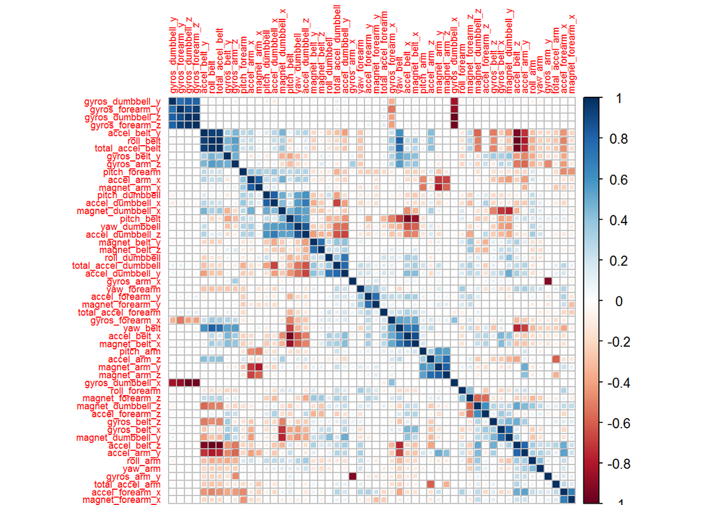

*Conclusion*: The great a amount of correlation among variables suggest that techniques such as PCA can be used to characterize the magnitude of the problem. PCA would also help reduce computation complexity and increase numerical stability.

# 5.0 - Model Building

To predict the *classe* variable, three classes of classification models were built with different pre-processing options using the **Caret** package. Given the nature of the prediction variable, regression models were ruled out of this analysis.

## 5.1 - Model Training

The table below details the different types of models that were trained with the training data set.

| Model Type | Model Class | Pre-Processing |
| --- | --- | --- |
| Random Forest | Classification Models: Classification Tree | None |
| Stochastic Gradient Boosting (gbm) | Classification Models: Rule Based | None |
| Support Vector Machines (svmRadial) | Classification Models: Nonlinear | Normalization (center, scale) |
| Random Forest | Classification Models: Classification Tree | PCA |
| Stochastic Gradient Boosting (gbm) | Classification Models:Rule Based | PCA |

The subsequent code blocks contain code and specific parameters used when training models. Furthermore, the doParallel library was utilized to take full advantage of multi-core machine architecture and improve run time.

** Model 1:Random Forest Model**

```r
# Enabeling multi-core processing
cl <- makeCluster(detectCores())
registerDoParallel(cl)

# Random Forest with PCA
set.seed(112)
modelFit_rf <- train(classe ~ ., data=training, method="rf", prox=TRUE)
```

** Model 2:Stochastic Gradient Boosting (gbm)**

```r
# Enabeling multi-core processing
cl <- makeCluster(detectCores())
registerDoParallel(cl)

set.seed(112)
modelFit_gbm <- train(classe ~ ., method="gbm", data=training, verbose=FALSE)
```

** Model 3:Support Vector Machines (svmRadial)**

```r
# Enabeling multi-core processing
cl <- makeCluster(detectCores())
registerDoParallel(cl)

set.seed(112)
modelFit_svm <- train(classe ~ ., data=training, method="svmRadial", preProc = c("center", "scale"), metric = "Accuracy")
```

** Model 4:Random Forest with PCA**

```r
# Enabeling multi-core processing
cl <- makeCluster(detectCores())
registerDoParallel(cl)

# Random Forest with PCA
set.seed(112)
modelFit_rf_PCA <- train(classe ~ ., data=training, method="rf",preProcess = "pca", prox=TRUE)
```

** Model 5:Stochastic Gradient Boosting (gbm) with PCA**

```r
# Enabeling multi-core processing
cl <- makeCluster(detectCores())
registerDoParallel(cl)

set.seed(112)
modelFit_gbm_PCA <- train(classe ~ ., method="gbm", preProcess = "pca", data=training, verbose=FALSE)
```

### 5.2 - Initial Model Evaluation

The trained models were evaluated against the cross-validation data sets. The results below indicate the out-of-sample metrics for all 5 models trained above. Further details on model evaluation on all five models can be found in *Appendix A: Initial Model Evaluation Detials*

| Model Name | Out of Sample Accuracy | 95% Confidence Interval for Accuracy | No Information Rate (NIR) | P-Value [Accuracy > NIR] | Kappa | Mcnemar’s Test P-Value |
| --- | --- | --- | --- | --- | --- | --- |
| Model 1:Random Forest Model | 0.982 | (0.98, 0.984) | 0.287 | <2e-16 (Significant) | 0.978 | N/A |
| Model 2:Stochastic Gradient Boosting (gbm) | 0.953 | (0.949, 0.956) | 0.29 | <2e-16 (Significant) | 0.94 | <2e-16 (Significant) |
| Model 3:Support Vector Machines (svmRadial) | 0.885 | (0.88, 0.891) | 0.302 | <2e-16 (Significant) | 0.855 | <2e-16 (Significant) |
| Model 4:Random Forest with PCA | 0.939 | (0.935, 0.943) | 0.289 | <2e-16 (Significant) | 0.923 | <2e-16 (Significant) |
| Model 5:Stochastic Gradient Boosting (gbm) with PCA | 0.8 | (0.793, 0.806) | 0.293 | <2e-16 (Significant) | 0.746 | <2e-16 (Significant) |

## 6.0 - Final Model Tuning

### 6.1 - Final Model Training

Given that *accuracy* was used as a metric to evaluate all the trained models, **Model 1:Random Forest Model** had the best performance. Hence, this model was further tuned to improve its accuracy.

In order to improve overall accuracy while prevent over-fitting, a k-fold cross validation (where k=10) was done while re-training the model.

The code below details the process.

```r
# Enabeling multi-core processing
cl <- makeCluster(detectCores())
registerDoParallel(cl)

set.seed(112)
fitControl <- trainControl(## 10-fold CV
                           method = "repeatedcv",
                           number = 10,
                           ## repeated ten times
                           repeats = 10)
modelFit_rf_CV <- train(classe ~ ., data=training, method="rf", trControl = fitControl, prox=TRUE)
```

### 6.2 - Final Model Evaluation

| Model Name | Out of Sample Accuracy | 95% Confidence Interval for Accuracy | No Information Rate (NIR) | P-Value [Accuracy > NIR] | Kappa | Mcnemar’s Test P-Value |
| --- | --- | --- | --- | --- | --- | --- |
| Final Model :Random Forest Model with K-Fold Cross Validation | 0.982 | (0.98, 0.984) | 0.287 | <2e-16 (Significant) | 0.978 | N/A |

As seen above, after the model tuning, the performance of the model has little-to-no improvement. Hence, if processing power was a limited resource, it is recommended that cross validation is not required in this case.

The figure below shows the scaled variable importance of the final model.

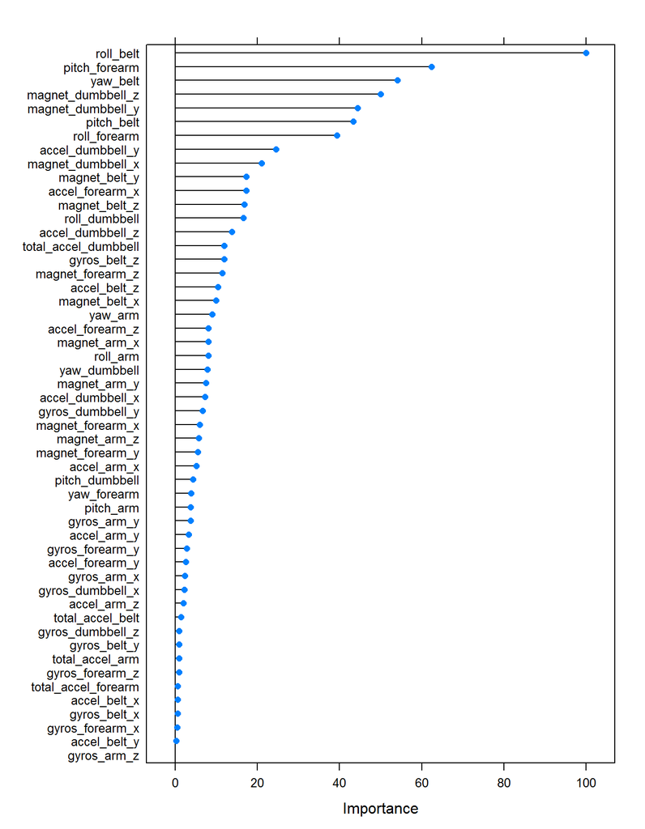

Hence, we see that the *roll_belt* is vital for model reduction and the subsequent 19 variables are major contributors to model accuracy.

Final model specifications:

- mtry: 27
- In-Sample Accuracy: 0.979
- Kappa: 0.973
- AccuracySD: 0.00613
- KappaSD: 0.00776
- Performance Metric: Accuracy

## 7.0 - Predicting the Results

### 7.1 - Prediction on the Test Set

| Prob(A) | Prob(B) | Prob(C) | Prob(D) | Prob(E) | Final Prediction |
| --- | --- | --- | --- | --- | --- |
| 0.08 | 0.79 | 0.09 | 0.03 | 0.02 | B |
| 0.92 | 0.05 | 0.01 | 0.00 | 0.01 | A |
| 0.10 | 0.67 | 0.17 | 0.01 | 0.04 | B |
| 0.90 | 0.00 | 0.05 | 0.05 | 0.00 | A |
| 0.96 | 0.01 | 0.02 | 0.00 | 0.01 | A |
| 0.01 | 0.13 | 0.11 | 0.05 | 0.69 | E |
| 0.03 | 0.01 | 0.14 | 0.77 | 0.05 | D |
| 0.06 | 0.50 | 0.13 | 0.23 | 0.08 | B |
| 1.00 | 0.00 | 0.00 | 0.00 | 0.00 | A |
| 1.00 | 0.00 | 0.00 | 0.00 | 0.00 | A |
| 0.05 | 0.49 | 0.34 | 0.07 | 0.04 | B |
| 0.03 | 0.15 | 0.71 | 0.03 | 0.07 | C |
| 0.02 | 0.92 | 0.01 | 0.00 | 0.06 | B |
| 1.00 | 0.00 | 0.00 | 0.00 | 0.00 | A |
| 0.01 | 0.03 | 0.04 | 0.01 | 0.91 | E |
| 0.04 | 0.09 | 0.01 | 0.04 | 0.82 | E |
| 0.97 | 0.00 | 0.00 | 0.00 | 0.03 | A |
| 0.06 | 0.73 | 0.01 | 0.15 | 0.05 | B |
| 0.11 | 0.85 | 0.01 | 0.02 | 0.01 | B |
| 0.00 | 1.00 | 0.00 | 0.00 | 0.00 | B |

## Appendix

### Appendix A: Initial Model Evaluation Detials

```r
confusionMatrix(crossVal$classe, predict(modelFit_rf, crossVal))
```

```
## Confusion Matrix and Statistics
##
##           Reference
## Prediction    A    B    C    D    E
##          A 3885   17    2    0    2
##          B   57 2561   36    3    0
##          C    0   25 2362    8    0
##          D    0    3   52 2189    7
##          E    0    7   18    6 2493
##
## Overall Statistics
##
##                Accuracy : 0.982
##                  95% CI : (0.98, 0.984)
##     No Information Rate : 0.287
##     P-Value [Acc > NIR] : <2e-16
##
##                   Kappa : 0.978
##  Mcnemar's Test P-Value : NA
##
## Statistics by Class:
##
##                      Class: A Class: B Class: C Class: D Class: E
## Sensitivity             0.986    0.980    0.956    0.992    0.996
## Specificity             0.998    0.991    0.997    0.995    0.997
## Pos Pred Value          0.995    0.964    0.986    0.972    0.988
## Neg Pred Value          0.994    0.995    0.990    0.999    0.999
## Prevalence              0.287    0.190    0.180    0.161    0.182
## Detection Rate          0.283    0.186    0.172    0.159    0.182
## Detection Prevalence    0.284    0.193    0.174    0.164    0.184
## Balanced Accuracy       0.992    0.986    0.977    0.993    0.997
```

```r
confusionMatrix(crossVal$classe, predict(modelFit_gbm, crossVal))
```

```
## Confusion Matrix and Statistics
##
##           Reference
## Prediction    A    B    C    D    E
##          A 3835   41   16    3   11
##          B  129 2411   95   10   12
##          C    1   69 2290   33    2
##          D    4   15   81 2130   21
##          E    8   26   28   45 2417
##
## Overall Statistics
##
##                Accuracy : 0.953
##                  95% CI : (0.949, 0.956)
##     No Information Rate : 0.29
##     P-Value [Acc > NIR] : <2e-16
##
##                   Kappa : 0.94
##  Mcnemar's Test P-Value : <2e-16
##
## Statistics by Class:
##
##                      Class: A Class: B Class: C Class: D Class: E
## Sensitivity             0.964    0.941    0.912    0.959    0.981
## Specificity             0.993    0.978    0.991    0.989    0.991
## Pos Pred Value          0.982    0.907    0.956    0.946    0.958
## Neg Pred Value          0.986    0.986    0.981    0.992    0.996
## Prevalence              0.290    0.187    0.183    0.162    0.179
## Detection Rate          0.279    0.176    0.167    0.155    0.176
## Detection Prevalence    0.284    0.193    0.174    0.164    0.184
## Balanced Accuracy       0.979    0.960    0.951    0.974    0.986
```

```r
confusionMatrix(crossVal$classe, predict(modelFit_svm, crossVal))
```

```
## Confusion Matrix and Statistics
##
##           Reference
## Prediction    A    B    C    D    E
##          A 3792   22   61   23    8
##          B  292 2134  195   11   25
##          C   25  128 2120  115    7
##          D   21   30  264 1923   13
##          E   11   72  136  114 2191
##
## Overall Statistics
##
##                Accuracy : 0.885
##                  95% CI : (0.88, 0.891)
##     No Information Rate : 0.302
##     P-Value [Acc > NIR] : <2e-16
##
##                   Kappa : 0.855
##  Mcnemar's Test P-Value : <2e-16
##
## Statistics by Class:
##
##                      Class: A Class: B Class: C Class: D Class: E
## Sensitivity             0.916    0.894    0.764    0.880    0.976
## Specificity             0.988    0.954    0.975    0.972    0.971
## Pos Pred Value          0.971    0.803    0.885    0.854    0.868
## Neg Pred Value          0.964    0.977    0.942    0.977    0.995
## Prevalence              0.302    0.174    0.202    0.159    0.163
## Detection Rate          0.276    0.155    0.154    0.140    0.160
## Detection Prevalence    0.284    0.193    0.174    0.164    0.184
## Balanced Accuracy       0.952    0.924    0.869    0.926    0.974
```

```r
confusionMatrix(crossVal$classe, predict(modelFit_rf_PCA, crossVal))
```

```
## Confusion Matrix and Statistics
##
##           Reference
## Prediction    A    B    C    D    E
##          A 3812   43   33   13    5
##          B  125 2390  118    4   20
##          C   10   68 2252   41   24
##          D   14   15  141 2068   13
##          E    6   51   49   47 2371
##
## Overall Statistics
##
##                Accuracy : 0.939
##                  95% CI : (0.935, 0.943)
##     No Information Rate : 0.289
##     P-Value [Acc > NIR] : <2e-16
##
##                   Kappa : 0.923
##  Mcnemar's Test P-Value : <2e-16
##
## Statistics by Class:
##
##                      Class: A Class: B Class: C Class: D Class: E
## Sensitivity             0.961    0.931    0.868    0.952    0.975
## Specificity             0.990    0.976    0.987    0.984    0.986
## Pos Pred Value          0.976    0.900    0.940    0.919    0.939
## Neg Pred Value          0.984    0.984    0.970    0.991    0.994
## Prevalence              0.289    0.187    0.189    0.158    0.177
## Detection Rate          0.278    0.174    0.164    0.151    0.173
## Detection Prevalence    0.284    0.193    0.174    0.164    0.184
## Balanced Accuracy       0.976    0.954    0.928    0.968    0.980
```

```r
confusionMatrix(crossVal$classe, predict(modelFit_gbm_PCA, crossVal))
```

```
## Confusion Matrix and Statistics
##
##           Reference
## Prediction    A    B    C    D    E
##          A 3447  149  152  134   24
##          B  272 1947  264   66  108
##          C  132  201 1911  105   46
##          D  102   61  248 1767   73
##          E   77  247  162  130 1908
##
## Overall Statistics
##
##                Accuracy : 0.8
##                  95% CI : (0.793, 0.806)
##     No Information Rate : 0.293
##     P-Value [Acc > NIR] : <2e-16
##
##                   Kappa : 0.746
##  Mcnemar's Test P-Value : <2e-16
##
## Statistics by Class:
##
##                      Class: A Class: B Class: C Class: D Class: E
## Sensitivity             0.855    0.747    0.698    0.802    0.884
## Specificity             0.953    0.936    0.956    0.958    0.947
## Pos Pred Value          0.882    0.733    0.798    0.785    0.756
## Neg Pred Value          0.941    0.941    0.927    0.962    0.978
## Prevalence              0.293    0.190    0.199    0.160    0.157
## Detection Rate          0.251    0.142    0.139    0.129    0.139
## Detection Prevalence    0.284    0.193    0.174    0.164    0.184
## Balanced Accuracy       0.904    0.842    0.827    0.880    0.915
```

### Appendix B: Final Model Evaluation Detials

```r
confusionMatrix(crossVal$classe, predict(modelFit_rf_CV, crossVal))
```

```
## Confusion Matrix and Statistics
##
##           Reference
## Prediction    A    B    C    D    E
##          A 3887   14    3    0    2
##          B   57 2561   38    1    0
##          C    0   29 2358    8    0
##          D    0    2   53 2189    7
##          E    0    8   17    5 2494
##
## Overall Statistics
##
##                Accuracy : 0.982
##                  95% CI : (0.98, 0.984)
##     No Information Rate : 0.287
##     P-Value [Acc > NIR] : <2e-16
##
##                   Kappa : 0.978
##  Mcnemar's Test P-Value : NA
##
## Statistics by Class:
##
##                      Class: A Class: B Class: C Class: D Class: E
## Sensitivity             0.986    0.980    0.955    0.994    0.996
## Specificity             0.998    0.991    0.997    0.995    0.997
## Pos Pred Value          0.995    0.964    0.985    0.972    0.988
## Neg Pred Value          0.994    0.995    0.990    0.999    0.999
## Prevalence              0.287    0.190    0.180    0.160    0.182
## Detection Rate          0.283    0.186    0.172    0.159    0.182
## Detection Prevalence    0.284    0.193    0.174    0.164    0.184
## Balanced Accuracy       0.992    0.986    0.976    0.994    0.997
```